# Визуализация биомедицинских данных. Домашнее задание

# О задании

В этом задании почти соблюдаются принципы классицизма: одно задание — не меньше одного графика и не меньше одного чанка, если не сказано иное. Правило действует, даже когда задание просит вернуться к предыдущему графику. При этом вы всегда можете расширить интерпретацию или показать то же самое ещё и другим, более подходящим, на ваш взгляд, способом — дополнительными графиками к заданию. Некоторые пункты касаются того, о чём на занятиях прямо не говорили, и потребуют справки и документации; обычно такие места оговорены в условии явно.

Инструкция по сдаче задания указана в `README.md` и на Stepik

## **Общие требования к оформлению**

1. Старайтесь соблюдать единый стиль оформления и структуру отчёта, если в задании не указано иное. Не оставляйте в финальном отчёте лишние чанки кода, текст или комментарии, которые не относятся к решению задания.
2. Любой output должен быть читаемым и достаточно кратким, чтобы было удобно просматривать. Не оставляйте «полотна» текста или вывода. Объёмный output оформите аккуратно, либо сократите, либо вовсе уберите. Таблицы оформляйте c пмощью flextable, а для графиков подбирайте подходящий размер и пропорции
3. Ответы на вопросы оформляйте в виде текста явно, не в виде комментариев к коду.
4. Сохраняйте исходную структуру проекта в репозитории. Не добавляйте лишние файлы, которые не относятся к проекту или выполнению заданий.
5. Оформление коммитов и веток на GitHub должно соответствовать общим правилам для всех курсов Института биоинформатики (см. соответствующий материал на курсе Python).

# Правила и требования для всех задач *в этом домашней задании*

**Выполняйте их, даже если в тексте задания они не упомянуты.**

- Под каждым графиком напишите интерпретацию: что на нём видно и какой вывод из этого следует, в 2–4 предложениях. Перечисление геомов и цветов интерпретацией не считается. Если вывода нет или данных для него мало, так и напишите.
- Делайте текст на графике настолько крупным, насколько позволяют сам график и ваше чувство меры. Читаемые надписи — важный (но не так уж часто встречающийся) элемент графиков.
- Не используйте фон ggplot2 по умолчанию.
- У каждого графика должен быть заголовок, отражающий его суть, и правильно названные оси.
- Все подписи на графиках — на русском языке.
- Старайтесь, чтобы графики были достаточно крупными и читались не только в отрендеренном HTML, но и при интерактивном запуске чанков в Positron.
- Однотипные графики стройте функцией (конспект 2, раздел «П6 · Функция для однотипных графиков (слайд П6)»).
- Цвета факультетов — как в конспектах: Гриффиндор `#B32025`, Хаффлпафф `#D7A900`, Рейвенкло `#2E5EAA`, Слизерин `#2F7D4A`. В задании 10 цвета берите с образца.

Для некоторых заданий понадобится пакет patchwork: он собирает несколько графиков в один (конспект 2, раздел «П9 · Несколько графиков на одну страницу (слайд П9)»). Советуем почитать его документацию и пользоваться им в домашней работе. Для задания 8 нужен пакет gghighlight. Если каких-то пакетов нет, установите их один раз в консоли: `install.packages(c("patchwork", "gghighlight"))`.

Если, пока вы строите и интерпретируете график, у вас появилась гипотеза, не стесняйтесь её проверить: постройте для того же задания ещё один график (или несколько), проведите дополнительное исследование.

# Подготовка

```r
library(tidyverse)
library(patchwork)
library(gghighlight)

hogwarts <- read_csv("data/hogwarts_2026.csv", show_col_types = FALSE)
```

# Задание 1

Постройте барплот (столбчатую диаграмму), отражающий распределение числа студентов по курсам обучения. Раскрасьте столбики любым понравившимся цветом: подойдёт и название цвета, и hex-код. Задайте и цвет контура столбиков. Проинтерпретируйте график.

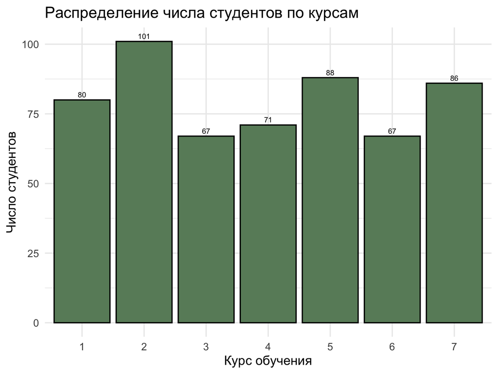

```r
hogwarts |>
  mutate(course = factor(course)) |>
  ggplot(aes(x = course)) +
  geom_bar(fill = "darkseagreen4", color = "black") +
  geom_text(aes(label = after_stat(count)), stat = 'count', vjust = -0.5, size = 3) +
  labs(title = "Распределение числа студентов по курсам", x = "Курс обучения", y = "Число студентов") +
  theme_minimal(base_size = 15)
```

**Интерпретация:**

Студенты распределены по курсам неравномерно. Больше всего студентов учится на 2 курсе, а меньше всего на 3 и 6 курсах. Cильный спад в количестве студентов после второго курса нельзя связать с массовыми отчислениями, так как на 5 курсе студентов больше, чем на 3 и 4 курсах. Если бы такая причина была реальной, число студентов после 2-го курса снижалось бы от курса к курсу.

# Задание 2

Постройте новый барплот, отражающий распределение числа студентов по факультетам. Добавьте на график вторую факторную переменную — происхождение (`bloodStatus`).

С помощью аргумента `position` измените график так, чтобы каждый столбец показывал распределение факультета по чистоте крови в долях. Запишите текстом в этом файле, какой вывод можно сделать из графика.

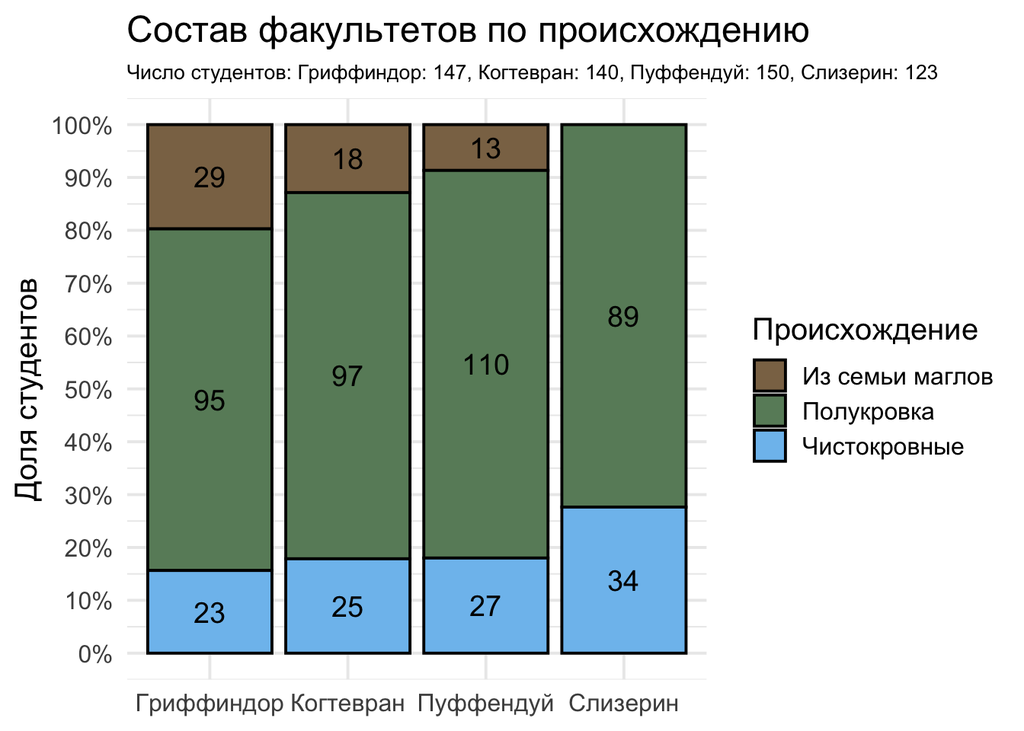

```r
 #| fig-width: 8
 #| fig-height: 6

blood_names <- c(
  `half-blood` = "Полукровка",
  `muggle-born` = "Из семьи маглов",
  `pure-blood` = "Чистокровные"
)

house_names <- c(
  `Gryffindor` = "Гриффиндор",
  `Hufflepuff` = "Пуффендуй",
  `Ravenclaw`  = "Когтевран",
  `Slytherin`  = "Слизерин"
)

blood_colours <- c(
  "Полукровка" = "darkseagreen4",
  "Из семьи маглов" = "burlywood4",
  "Чистокровные" = "skyblue2"
)


hogwarts |>
  mutate(house = recode_values(house, from = names(house_names), to = house_names), bloodStatus = recode_values(bloodStatus, from = names(blood_names), to = blood_names)) |>
  ggplot(aes(x = house, fill = bloodStatus)) +
  geom_bar(position = "fill", color = "black") +
  geom_text(aes(label = after_stat(count)), stat = "count",
            position = position_fill(vjust = 0.5), size = 5) +
  scale_fill_manual(values = blood_colours) +
  scale_y_continuous(n.breaks = 10, labels = scales::label_percent()) +
  labs(
    title = "Состав факультетов по происхождению",
    y = "Доля студентов", x = NULL, fill = "Происхождение",
    subtitle = "Число студентов: Гриффиндор: 147, Когтевран: 140, Пуффендуй: 150, Слизерин: 123") +
  theme_minimal(base_size = 15) +
  theme(plot.subtitle = element_text(size = 10))
```

**Вывод:**

Из графика состава факультетов по происхождению видно, что на всех факультетах больше всего полукровок: от ~65% в Гриффиндоре до ~75% в Пуффендуе. Чистокровных студентов больше всего в Слизерине ~30% (что совсем неудивительно), а меньше всего в Гриффиндоре, но, стоит отметить, что их доля почти одинакова у всех факультетов, кроме Слизерина. Таким образом, можно сказать, что самый разнообразный состав по происхождению у Гриффиндора, а Слизерин отличился отсутствием маглорожденных студентов и наибольшим количеством чистокровок.

# Задание 3

Отобразите распределение баллов, заработанных студентами на 3-й неделе обучения, по факультетам. Постарайтесь показать одновременно и форму распределения, и некоторые описательные статистики. Отсортируйте факультеты в порядке убывания медианного балла за 3-ю неделю (функция, которую мы разбирали на слайде 21, по умолчанию сортирует именно по медиане, так что задавать медиану отдельным аргументом не нужно). Если используете `geom_jitter()`, постарайтесь, чтобы точки лежали кучнее вдоль оси, которая не отражает само распределение. Проинтерпретируйте график.

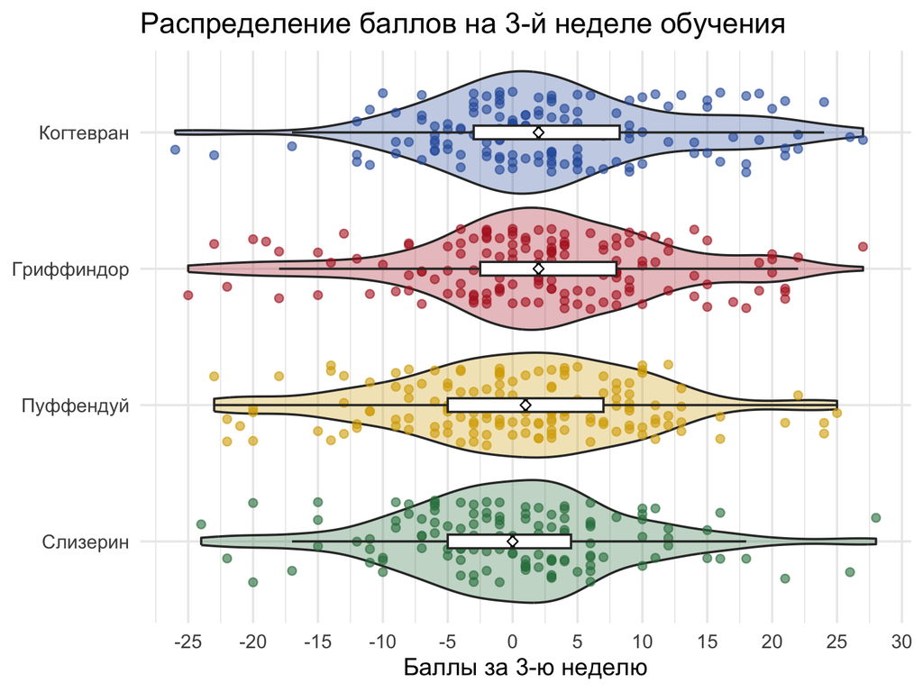

```r
house_colours <- c(
  "Гриффиндор" = "#B32025", "Пуффендуй" = "#D7A900",
  "Когтевран"= "#2E5EAA", "Слизерин" = "#2F7D4A"
)

hogwarts |>
  select(house, week_3) |>
  mutate(house = fct_reorder(recode_values(house, from = names(house_names), to = house_names), week_3, .fun = median)) |>
  ggplot(aes(x = week_3, y = house)) +
  geom_violin(aes(fill = house), alpha = 0.3)  +
  geom_jitter(aes(color = house), alpha = 0.6, width = 0, height = 0.3) +
  geom_boxplot(width = 0.1, fill = "white", outliers = FALSE) +
  stat_summary(fun = median, geom = "point", shape = 23, size = 2, fill = "white", color = "black") +
  scale_color_manual(values = house_colours) +
  scale_fill_manual(values = house_colours) +
  guides(color = "none", fill = "none") +
  theme_minimal(base_size = 15) +
  labs(x = "Баллы за 3-ю неделю", y = NULL, title = "Распределение баллов на 3-й неделе обучения", color = "Факультет") +
  scale_x_continuous(n.breaks = 10)
```

**Интерпретация:**

На графике изображено распределение баллов за 3-ю неделю обучения по факультетам. У всех факультетов баллы распределены похожим образом: от -30 до +30. Медианы лежат около нуля и почти не различаются: наибольшие значения у Гриффиндора и Когтеврана, а наименьшее значение медианы у Слизерина. Примечательно, что распределение баллов студентов Когтеврана сдвинуто правее относительно других факультетов (точки и ящик правее), видимо, в среднем студенты получают положительные отметки чаще, чем студенты других факультетов. У Слизерина же ящик самый узкий и сдвинут влево (-5 до +4.5). Более того, если обратить внимание на “усы”, то у Слизерина верхний “ус” короче, чем у других факультетов. Тем не менее, несмотря на разбросы баллов внутри групп, различия в медианных значениях малы, поэтому нельзя сказать, что какой-либо факультет проучился хуже или лучше остальных.

# Задание 4

Постройте гистограмму результатов любого экзамена на ваш выбор, кроме зельеварения. Настройте оптимальное, на ваш взгляд, число столбцов гистограммы. Выполните фасетирование по курсу. Постарайтесь, чтобы график был по возможности компактным. Проинтерпретируйте график.

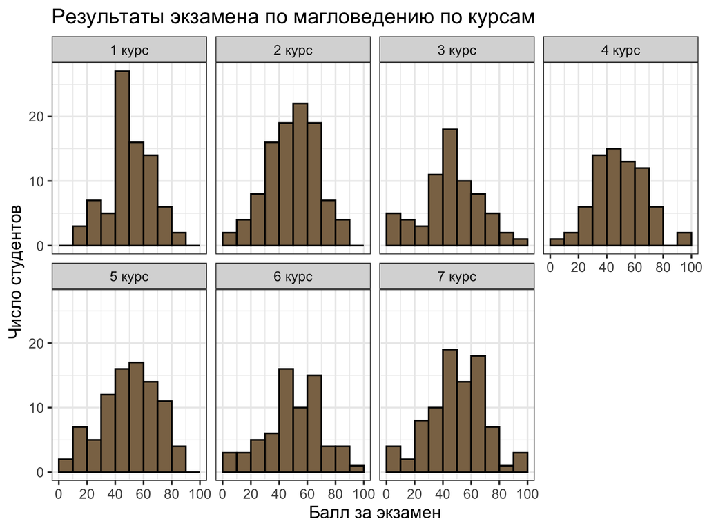

```r
hogwarts |>
  select(`Muggle studies exam`, course) |>
  mutate(course = factor(course)) |>
  ggplot(aes(x = `Muggle studies exam`)) +
  geom_histogram(binwidth = 10, fill = "burlywood4", color = "black", boundary = 0) +
  facet_wrap(vars(course), nrow = 2, labeller = as_labeller(~ paste(.x, "курс"))) +
  labs(y = "Число студентов", x = "Балл за экзамен", title = "Результаты экзамена по магловедению по курсам") +
  scale_x_continuous(n.breaks = 8) +
  theme_bw(base_size = 14)
```

**Интерпретация:** На графике видно, что у всех курсов распределение баллов за экзамен по магловедению принимает симметричный вид с центром в 50 баллах. Наиболее узкое распределение у 1 курса, больше 20 учащихся получили от 40 до 50 баллов, а баллов ниже 10 нет вовсе. Наиболее интересная картина у 7 курса, там больше всего студентов набравших от 90 до 100 баллов, при этом на этом же курсе есть примерно такое же количество студентов, набравших меньше 10 баллов. Исходя из графика, можно сказать, что у всех курсов схожий средний уровень, а различия могут объяснятся разбросом внутригрупповых результатов.

# Задание 5

Постройте скаттерплот, показывающий связь между суммарным баллом студента за год и оценкой за экзамен (по травологии, магловедению, нумерологии и зельеварению). Добавьте на график линию тренда. Удалите доверительную область и сделайте линию прямой. Подумайте, как обойтись без того, чтобы записывать одни и те же координаты x и y дважды. Проинтерпретируйте график.

Раскрасьте точки в разные цвета в соответствии с факультетами. Проинтерпретируйте полученный результат.

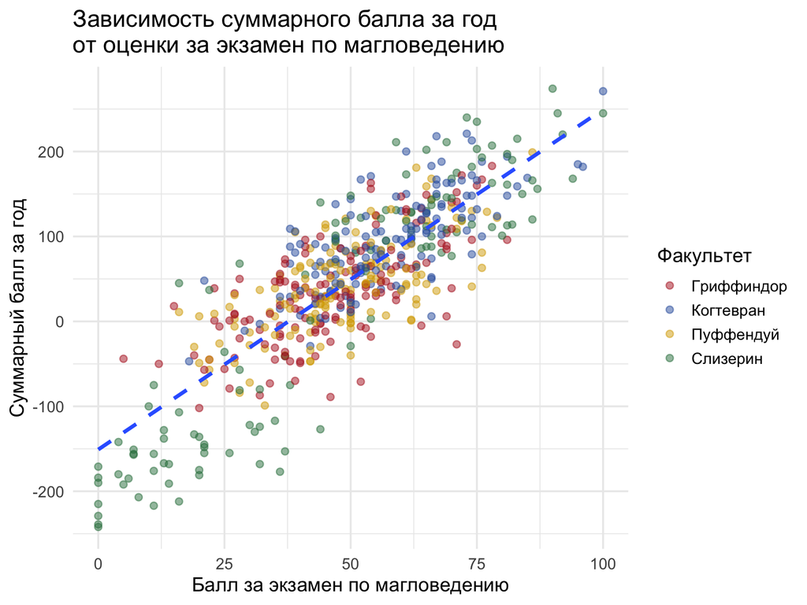

```r
sex_names <- c(
  `female` = "Женский",
  `male` = "Мужской"
)

hogwarts |>
  select(house, `Muggle studies exam`, result) |>
  mutate(
    house = recode_values(house, from = names(house_names), to = house_names),
    house = factor(house)
    ) |>
  ggplot(aes(x = `Muggle studies exam`, y = result)) +
  geom_point(aes(color = house), size = 2, alpha = 0.5) +
  geom_smooth(method = "lm", formula = y ~ x, se = FALSE, linetype = "dashed") +
  labs(y = "Суммарный балл за год", x = "Балл за экзамен по магловедению",
  title = "Зависимость суммарного балла за год\nот оценки за экзамен по магловедению",
  color = "Факультет"
  ) +
  scale_color_manual(values = house_colours) +
  theme_minimal(base_size = 14)
```

**Интерпретация:**

На графике видна положительная линейная связь между суммарным баллом за год и баллом за экзамен по магловедению. То есть, чем выше балл за экзамен по магловедению, тем выше суммарный балл студента за год. Линия тренда пересекает ось y в точке -150, что соответствует 0 баллам за экзамен, а следует она до отметки 250 (100 баллов за экзамен), то есть каждые 10 баллов за экзамен по магловедению увеличивают суммарный балл за год примерно на 40 баллов. Однако, точки не лежат на самой линии, а довольно сильно разбросаны вокруг нее, поэтому нельзя однозначно предсказать какой суммарный балл получит студент, основываясь на балл за экзамен по магловедению.

# Задание 6

Сравните распределение баллов за экзамен по прорицанию и за экзамен по защите от тёмных искусств. Сделайте это тремя разными способами. Под разными способами понимаются идеологически разные геомы или способы группировки. Не считаются разными способами изменения константных визуальных параметров (цвет заливки, размер фигур, другие чисто стилевые отличия) на сходных в остальном графиках.

Объедините графики так, чтобы итоговый график имел два столбца и две строки. Два графика должны стоять в верхней строке и занимать равную площадь. Третий график должен занимать нижнюю строку целиком. Проинтерпретируйте график.

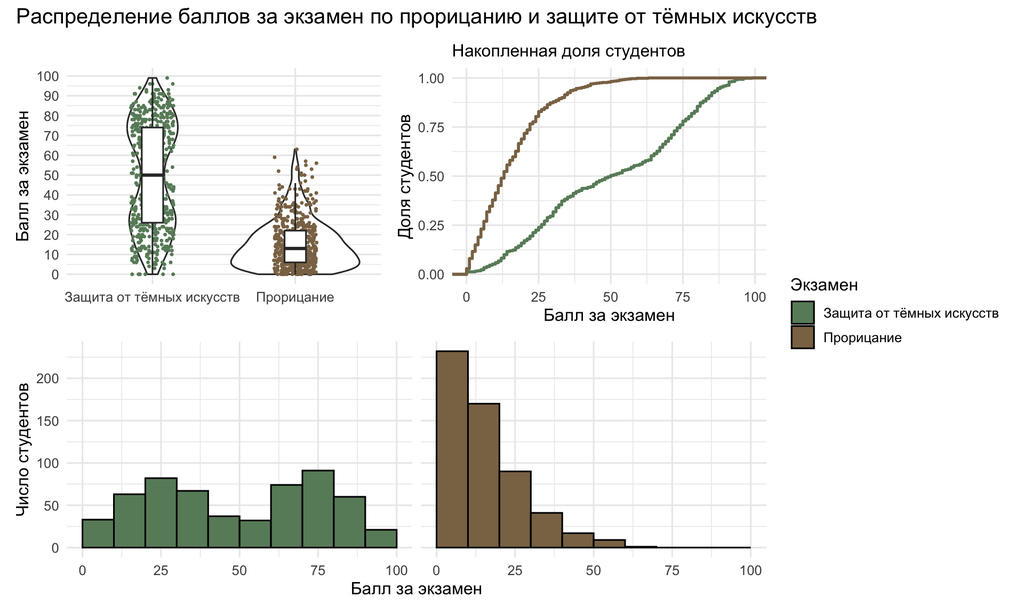

```r
two_exam_colors <- c(
  "Защита от тёмных искусств" = "darkseagreen4",
  "Прорицание" = "burlywood4")

two_exams <- hogwarts |>
  select(`Defence against the dark arts exam`, `Divinations exam`) |>
  pivot_longer(cols = everything(), names_to = "exam", values_to = "score") |>
  mutate(exam = fct_recode(exam, "Защита от тёмных искусств" = "Defence against the dark arts exam", "Прорицание" = "Divinations exam"))

plot_1 <- two_exams |> ggplot(aes(x = exam, y = score)) +
  geom_violin() +
  geom_jitter(aes(color = exam), size = 0.5, width = 0.15, height = 0) +
  geom_boxplot(width = 0.15, outliers = FALSE) +
  labs(y = "Балл за экзамен", x = NULL) +
  scale_color_manual(values = two_exam_colors) +
  guides(color = "none") +
  scale_y_continuous(n.breaks = 10) +
  theme_minimal(base_size = 12)

plot_2 <- two_exams |> ggplot(aes(x = score, fill = exam)) +
  geom_histogram(color = "black", binwidth = 10, boundary = 0) +
  facet_wrap(vars(exam)) +
  labs(x = "Балл за экзамен", y = "Число студентов", fill = "Экзамен") +
  scale_fill_manual(values = two_exam_colors) +
  guides(color = "none") +
  theme_minimal(base_size = 12)  +
  theme(strip.text = element_blank())

plot_3 <- ggplot(two_exams, aes(x = score, color = exam)) +
  stat_ecdf(linewidth = 1) +
  scale_color_manual(values = two_exam_colors) +
  labs(title = "Накопленная доля студентов", x = "Балл за экзамен",
       y = "Доля студентов", color = "Экзамен") +
  guides(color = "none") +
  theme_minimal(base_size = 12) +
  theme(plot.title = element_text(size = 12))

(plot_1 | plot_3) / plot_2 + plot_annotation(title = "Распределение баллов за экзамен по прорицанию и защите от тёмных искусств", theme = theme(plot.title = element_text(size = 15))) + plot_layout(guides = "collect")
```

**Интерпретация:**

Распределения баллов по двум экзаменам заметно отличаются. По защите от тёмных искусств баллы разбросаны почти по всей шкале: медиана около 50, а половина студентов набрала от 25 до 75 баллов. На гистограмме видно две вершины (около 25 и около 75 баллов), студенты поделились на два лагеря: те, кто сдал хорошо и те, кто сдал удовлетворительно. По прорицанию баллы сильно смещены в сторону низких значений: медиана около 10, половина студентов набрала от 5 до 20 баллов, а больше 65 баллов не получил никто. По кривой накопленной доли видно, что около 80% студентов набрали по прорицанию не больше 25 баллов, а по защите на этом уровне находится лишь примерно четверть. Таким образом, можно сделать вывод, что прорицание давалось студентам намного сложнее, чем защита от тёмных искусств.

# Задание 7

Постройте диаграмму рассеяния (скаттерплот), где по осям отложены результаты экзаменов по заклинаниям и по древним рунам. На графике есть некоторая проблема. Если вам трудно её определить, возьмите подсказку: постройте скаттерплот по данным из файла `data/podskazka.csv`. По оси x отложите переменную `y`, по оси y — переменную `x`, а пределы оси y задайте от 200 до 500. Предложите и подкрепите визуализациями не менее трёх способов решить эту проблему.

### 1 способ

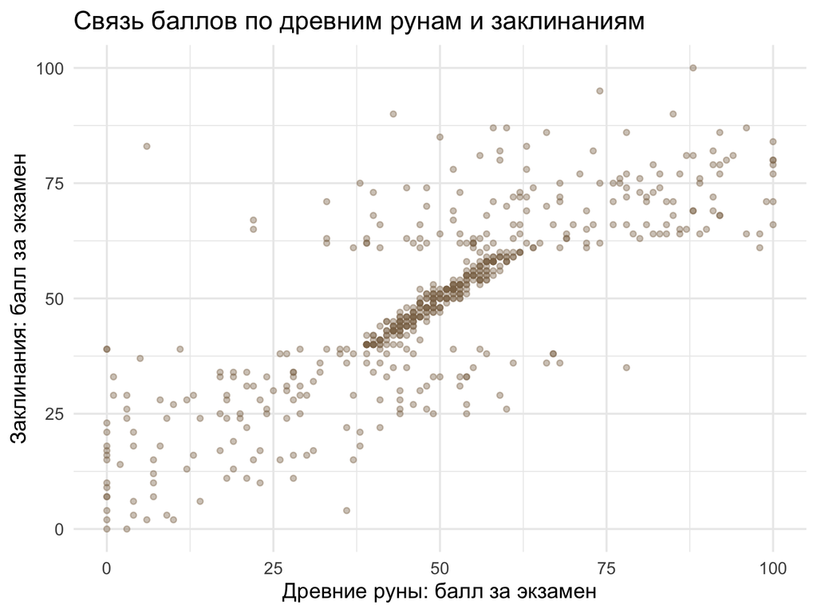

```r
draft_plot <- hogwarts |> select("Study of ancient runes exam", "Charms exam") |>
  ggplot(aes(x = `Study of ancient runes exam` , y = `Charms exam`))

draft_plot +
  geom_point(alpha = 0.4, size = 1.5, color = "burlywood4") +
  labs(x = "Древние руны: балл за экзамен", y = "Заклинания: балл за экзамен", title = "Связь баллов по древним рунам и заклинаниям") +
  theme_minimal(base_size = 15)
```

### 2 способ

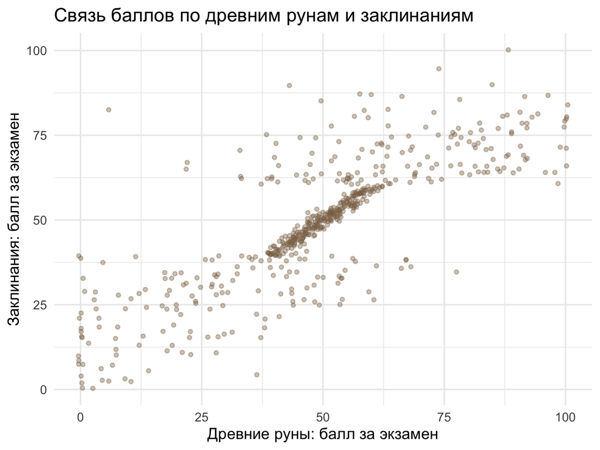

```r
draft_plot +
  geom_jitter(color = "burlywood4", width = 0.5, height = 0.5, alpha = 0.4, size = 1.5) +
  labs(x = "Древние руны: балл за экзамен", y = "Заклинания: балл за экзамен", title = "Связь баллов по древним рунам и заклинаниям") +
  theme_minimal(base_size = 15)
```

### 3 способ

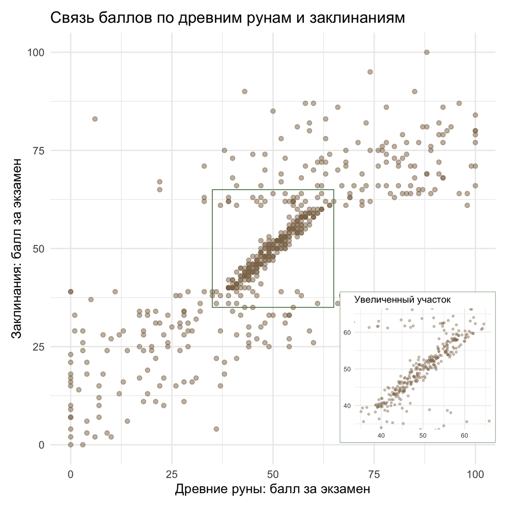

```r
plot_1_1 <- draft_plot +
  geom_point(alpha = 0.5, size = 2, color = "burlywood4") +
  annotate("rect", xmin = 35, xmax = 65, ymin = 35, ymax = 65, fill = NA, linewidth = 0.5, color = "darkseagreen4") +
  labs(x = "Древние руны: балл за экзамен", y = "Заклинания: балл за экзамен", title = "Связь баллов по древним рунам и заклинаниям") +
  theme_minimal(base_size = 15)

plot_1_2 <- draft_plot + geom_jitter(alpha = 0.4, size = 1, color = "burlywood4", width = 0.5, height = 0.5) +
  labs(title = "Увеличенный участок", x = NULL, y = NULL) +
  coord_cartesian(xlim = c(35, 65), ylim = c(35, 65)) +
  theme_minimal(base_size = 9) +
  theme(plot.background = element_rect(fill = "white", color = "darkseagreen4"))

plot_1_1 + inset_element(plot_1_2, left = 0.65, bottom = 0.05, right = 1, top = 0.40)
```

**Проблема и способы её решения:**

На графике много точек накладывается друг на друга. Баллы за экзамены целые, поэтому у многих студентов одинаковые пары значений, и в центре графика (около 40–60 баллов по обоим экзаменам) точки сливаются в сплошную полосу. По такому графику нельзя понять, сколько студентов находится в этой области

1 способ - изменение прозрачности и уменьшение размера точек 2 способ - добавление небольшого случайного сдвига с помощью geom_jitter 3 способ - увеличение участка с одновременным применением 1-го и 2-го способов

Связь между баллами положительная и почти линейная: чем выше балл по древним рунам, тем выше по заклинаниям. Больше всего студентов лежит вдоль диагонали от 40 до 60 баллов, а несколько выбросов (например, около 6 баллов по рунам и 80 по заклинаниям) остаются отдельными точками

# Задание 8

Используйте таблицу с баллами по неделям для первых 30 студентов, которую мы получили на занятии (`first_30`, конспект 2, раздел «Линии: `group`, спагетти, акцент, профиль (слайд 53)»). В ней пока нет столбца `bloodStatus`, а он понадобится для подписей. Постройте лайнплоты для всех студентов. Выделите при помощи пакета gghighlight студентов факультета Рейвенкло, на лейблах отразите их происхождение.

Линии студентов других факультетов покрасьте в нейтральный серый цвет и задайте его явно, а их толщину сделайте не больше трети стандартной. Проинтерпретируйте график.

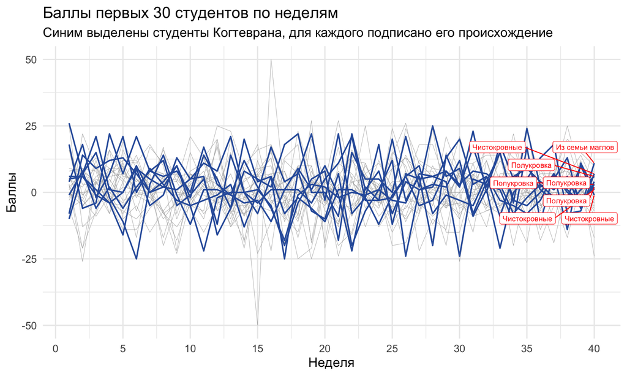

```r
weeks_long <- hogwarts |>
  select(id, house, bloodStatus, starts_with("week_")) |>
  pivot_longer(
    cols = starts_with("week_"),
    names_to = "week",
    values_to = "points"
  ) |>
  mutate(week = parse_number(week))

first_30 <- weeks_long |> filter(id <= 30) |> mutate(bloodStatus = recode_values(bloodStatus, from = names(blood_names), to = blood_names))

ggplot(first_30, aes(x = week, y = points, group = id)) +
  geom_line(aes(color = house), linewidth = 0.8) +
  gghighlight(house == "Ravenclaw", use_group_by = FALSE, label_key = bloodStatus, unhighlighted_params = list(linewidth = 0.2, colour = "grey70"), label_params = list(size = 3, color = "red", max.overlaps = Inf)) +
  scale_colour_manual(values = c("Ravenclaw" = "#2E5EAA"))  +
  labs(title = "Баллы первых 30 студентов по неделям", x = "Неделя", y = "Баллы", subtitle = "Синим выделены студенты Когтеврана, для каждого подписано его происхождение") +
  scale_x_continuous(n.breaks = 10) +
  theme_minimal(base_size = 15)
```

**Интерпретация:** …

Баллы студентов от недели к неделе сильно колеблются вокруг нуля (примерно от −25 до +25), и устойчивого роста или падения нет ни у кого. Линии студентов Когтеврана идут в том же диапазоне, что и остальные, и по происхождению (полукровки, чистокровные, из семьи маглов) заметных различий нет. Лишь один студент другого факультета выбивается резкими скачками на 15–16 неделях. По графику трудно сделать выводы, так как линии много и они пересекаются, но общая картина говорит об отсутствии выраженных различий

# Задание 9

Подробно (останавливаясь на каждом пункте, а не в общем) опишите, какие стороны графика и интерпретации (она приводится ниже) вы считаете верными и сделанными в соответствии с хорошими практиками, а какие — нет. Сделайте свой график, который отвечает на тот же исследовательский вопрос, но лишён технических и интерпретационных недостатков оригинала (если вы таковые нашли и упомянули).

График лежит в файле `images/task_2_4.png`:

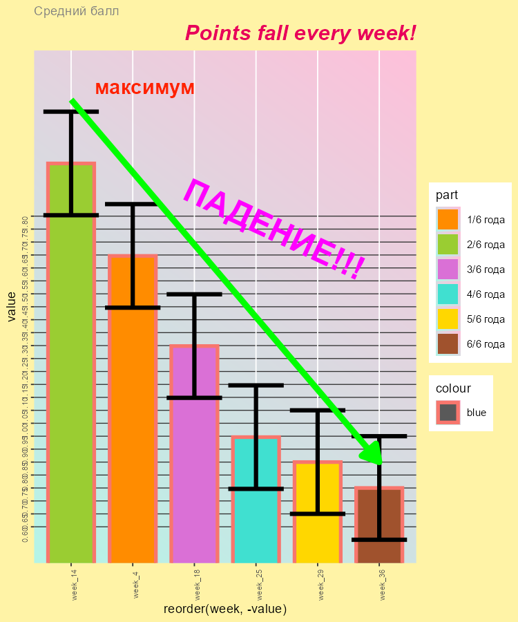

График к заданию 9

Интерпретация графика:

> В ходе исследования, проведенного в ФГБОУССО «Хогвартс» (далее Хогвартс) для оценки успешности образовательного процесса и психоэмоционального состояния участников вышеназванного процесса, были выявлены тревожные закономерности. А именно — при оценке среднего балла, полученного в течение недели совокупностью учащихся Хогвартса, была выявлена тенденция к резкому снижению данного показателя с течением времени. Так, в начале учебного процесса студенты набирали в среднем 2 балла (максимальный показатель). В последующие недели балл достоверно снижался, достигая минимальных значений к концу года (см. рис. 1). Мы полагаем, что данный процесс связан с ухудшением психологического состояния преподавателей означенного учебного заведения. Таким образом, в течение года они от мотивирующих мер положительного характера (добавление баллов за правильные ответы на занятиях и успехи во внеучебной деятельности) переходят к репрессивным действиям (учащающийся и увеличивающийся по модулю отъем баллов факультета за предполагаемые нарушения дисциплины, недостаточную, по мнению преподавателя, подготовку к занятию и пр.). Это вызывает снижение у учащихся мотивации к получению знаний, что вызывает следующий шаг снижения средненедельного балла — т.о., поведение педагогов вызывает своего рода circulus vitiosus.

> По итогам исследования и с учетом полученных результатов предлагается следующее: произвести замену профессорско-преподавательского состава с заменой педагогов, наиболее подверженных выгоранию в течение года (проявляющемуся в виде систематического снижения баллов студентам). Издать декрет о недопущении избыточного штрафования учащихся, начиная с 18-й недели учебного процесса до конца года. К нарушителям применять взыскания материально-магического характера. Объявить выговор с занесением в личное дело текущим представителям руководящего состава Хогвартса (далее дирекция).

**Разбор графика и интерпретации:**

Недостатки исходного графика:

1. Недели расставлены не по времени, а по убыванию значения, поэтому «падение» получается само собой.
2. Показаны только 6 недель из 40.
3. Оси названы кодом (value, reorder(week, -value))
4. Цвета и легенды лишние, оформление (фон, стрелка, «ПАДЕНИЕ!!!») мешает, заголовок на английском и неверный
5. Ось y не начинается с нуля, подписи на ней нечитаемы

Недостатки интерпретации:

1. Вывод о «резком снижении» держится на порядке столбцов и выбранных неделях
2. «2 балла в начале года (максимум)» не верно: максимум на 14-й неделе, а “Достоверно” сказано без какой-либо проверки
3. Причины (выгорание преподавателей) в данных не измерены, поэтому нельзя построить из графика причинно-следственную связь

На моем графике:

1. Средний балл по всем 40 неделям в хронологическом порядке с полосой стандартной ошибки (шесть недель из исходного графика я отметила зелеными точками)
2. Средний балл колеблется между 0.5 и 2 без устойчивого снижения, а выбранные недели попали на пики и провалы, поэтому оригинал создавал картину падения, которой нет на полных данных

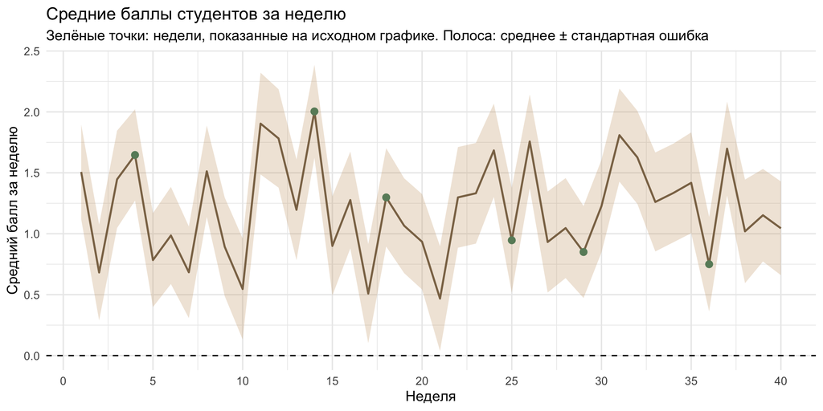

```r
selected_weeks <- c(4, 14, 18, 25, 29, 36)

mean_scores <- hogwarts |>
  select(starts_with("week_")) |>
  pivot_longer(cols = everything(), names_to = "week", values_to = "score") |>
  mutate(week = parse_number(week)) |>
  group_by(week) |>
  summarise(mean_score = mean(score), se = sd(score) / sqrt(n()))

mean_scores |>
  ggplot(aes(x = week, y = mean_score)) +
  geom_ribbon(aes(ymin = mean_score - se, ymax = mean_score + se), color = NA, fill = "burlywood3", alpha = 0.3) +
  geom_line(color = "burlywood4", linewidth = 1) +
  geom_point(data = filter(mean_scores, week %in% selected_weeks), color = "darkseagreen4", size = 3) +
  geom_hline(yintercept = 0, linetype = "dashed") +
  scale_x_continuous(n.breaks = 10) +
  labs(x = "Неделя", y = "Средний балл за неделю", title = "Средние баллы студентов за неделю", subtitle = "Зелёные точки: недели, показанные на исходном графике. Полоса: среднее ± стандартная ошибка") +
  theme_minimal(base_size = 15)
```

# Задание 10 (дополнительное)

Воспроизведите график максимально близко к оригиналу и проинтерпретируйте его. Постарайтесь максимально точно отразить каждый элемент.

Образец лежит в файле `images/task_10.png`:

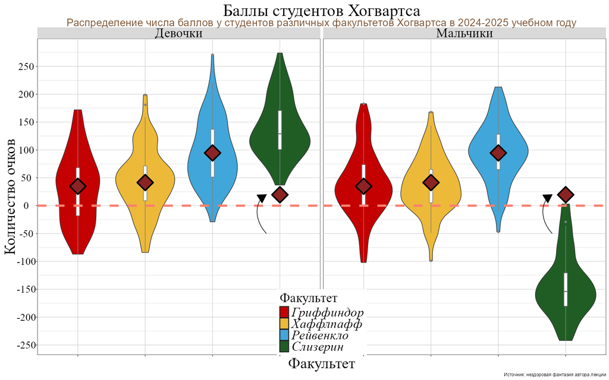

Образец к заданию 10

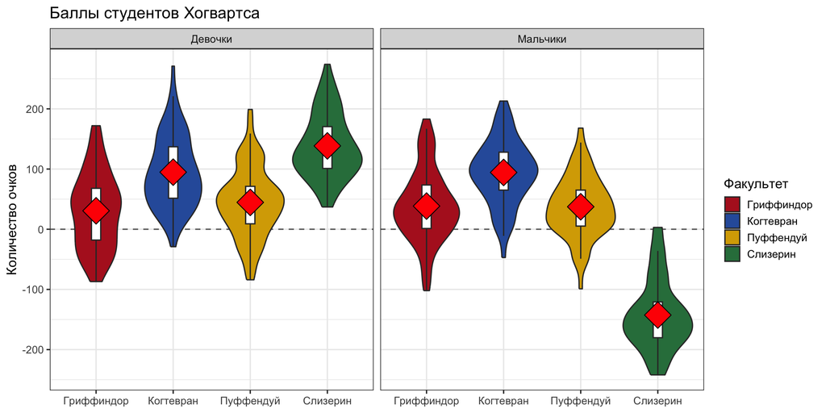

```r
hogwarts_total <- hogwarts |>
  mutate(total = rowSums(across(starts_with("week_"))),
         house = recode_values(house, from = names(house_names), to = house_names))

means <- hogwarts_total |>
  group_by(house, sex) |>
  summarise(mean_total = mean(total), .groups = "drop")

ggplot(hogwarts_total, aes(x = house, y = total, fill = house)) +
  geom_hline(yintercept = 0, linetype = "dashed", color = "gray40") +
  geom_violin() +
  geom_boxplot(width = 0.12, fill = "white", outliers = FALSE) +
  geom_point(data = means, aes(y = mean_total), shape = 23, size = 10, fill = "red", color = "black") +
  facet_wrap(vars(sex), labeller = as_labeller(c(female = "Девочки", male = "Мальчики"))) +
  scale_fill_manual(values = house_colours)  +
  labs(title = "Баллы студентов Хогвартса",
       x = NULL, y = "Количество очков", fill = "Факультет") +
  theme_bw(base_size = 14)
```